# Course 2 Section 3.9 - YOUR TURN

Jiaying Wu

16/10/2020

```r
#load library
library(tidyverse)
library(broom)
library(lubridate)
```

```r
# Load PISA data file if stored in folder named "data"
load(here::here("data","pisa_au.rda"))
```

### Step 1: Create a variable

Create a variable called science, which represents the student’s science score based on the average of 10 plausible value (PV) scores in science.

```r
# Create data frame of science scores
pisa_au_science <- pisa_au %>%
  # Create science score based on the 10 PV science scores
  mutate(science = (PV1SCIE + PV2SCIE + PV3SCIE + PV4SCIE + PV5SCIE +
    PV6SCIE + PV7SCIE + PV8SCIE + PV9SCIE + PV10SCIE) / 10)
```

### Step 2: Rename variables

Rename the following variables so that they better reflect what they represent:

- ST094Q01NA represents the student’s enjoyment of science.
- SMINS represents the student’s time spent studying science per week.
- W_FSTUWT represents the student’s weighting, which is an indication of how many other students they represent in Australia, relative to their socioeconomic and demographic characteristics.
- ST004D01T represents the student’s gender (NA is also a category here but there are no NAs for this variable in this data set). Any ‘missingness’ in this variable is information and should not be removed or corrected.
- ANXTEST represents the student’s test anxiety level.

```r
pisa_au_science <- pisa_au_science %>%
  # Select and rename ambiguous names
  select(science, science_fun = ST094Q01NA, science_time = SMINS,
    stuweight = W_FSTUWT, gender=ST004D01T, anxtest = ANXTEST) %>%
  # Recode gender variable
  mutate(gender = factor(gender,
                            levels=c(1,2),
                            labels=c("girl", "boy")), exclude = NULL)
```

### Step 3: Filter and convert

Filter out anomalies and missing values, and then convert the variables into appropriate classes.

```r
pisa_au_science <- pisa_au_science %>%
  # Filter out missing values in science_time
  filter(!is.na(science_fun), !is.na(science_time)) %>%
  # Convert science_fun into a factor
  mutate(
    science_fun = as.factor(science_fun),
    science_time = as.numeric(science_time)
  ) %>%
  # Filter for science_time greater than 0
  filter(science_time > 0)
```

### Relationship between science score and time spend studying science

#### Q1.If you did not apply a log transformation to study time, how would you describe its distribution?

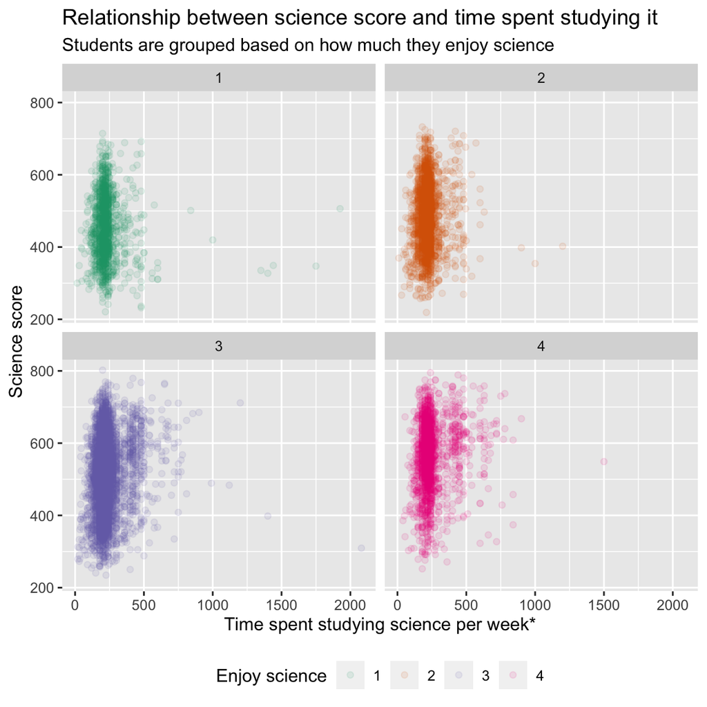

```r
pisa_au_science %>%
  ggplot(aes(x = science_time, y = science, colour = science_fun)) +
  geom_point(alpha = 0.1) +
  facet_wrap(~ science_fun, ncol = 2) +
  scale_colour_brewer("Enjoy science", palette = "Dark2") +
  theme(legend.position = "bottom") +
  ggtitle("Relationship between science score and time spent studying it") +
  labs(subtitle = "Students are grouped based on how much they enjoy science") +
  xlab("Time spent studying science per week*") +
  ylab("Science score")
```

The study time mostly clumped on the left with a right skewed.

#### Q2.Based on the log scaled x-axis, how would you describe the relationship between science score and time spent studying?

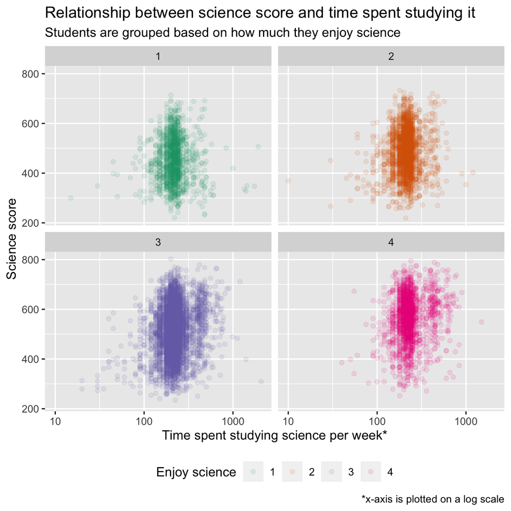

```r
pisa_au_science %>%
  ggplot(aes(x = science_time, y = science, colour = science_fun)) +
  geom_point(alpha = 0.1) +
  facet_wrap(~ science_fun, ncol = 2) +
  scale_colour_brewer("Enjoy science", palette = "Dark2") +
  # log-scale the x-axis
  scale_x_log10() +
  theme(legend.position = "bottom") +
  ggtitle("Relationship between science score and time spent studying it") +
  labs(subtitle = "Students are grouped based on how much they enjoy science",
       caption = "*x-axis is plotted on a log scale") +
  xlab("Time spent studying science per week*") +
  ylab("Science score")
```

More time spent on studying seems to give higher scores. Most of the scores are widely distributed in the middle section, around the median for time spent.

#### Q3.Are students who enjoy science more likely to receive higher scores, given they spend an equal amount of time studying science?

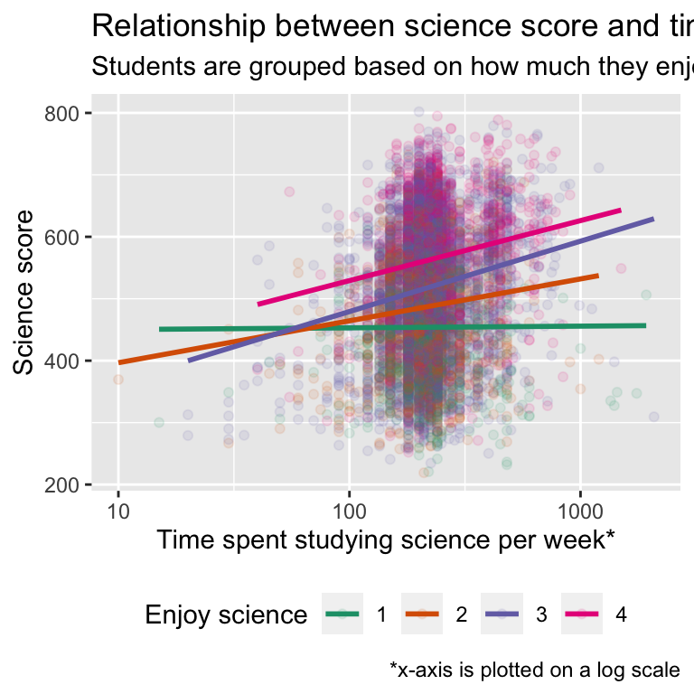

```r
pisa_au_science %>%
  ggplot(aes(x = science_time, y = science, colour = science_fun)) +
  geom_point(alpha = 0.1) +
  #facet_wrap(~ science_fun, ncol = 4) +
  geom_smooth(method = "lm", se = FALSE) +
  scale_colour_brewer("Enjoy science", palette = "Dark2") +
  # log-scale the x-axis
  scale_x_log10() +
  theme(legend.position = "bottom") +
  ggtitle("Relationship between science score and time spent studying it") +
  labs(subtitle = "Students are grouped based on how much they enjoy science",
       caption = "*x-axis is plotted on a log scale") +
  xlab("Time spent studying science per week*") +
  ylab("Science score")
```

Given they spend an equal amount of time studying science, students who enjoy science more likely to receive higher scores.

### Interpret model outputs

fit the 2 models of student’s science scores using the pisa_au_science data.

Using the output of both fitted models:

```r
# Fit both models of student's science score
mod1 <- lm(science ~ log10(science_time) + science_fun,
  data = pisa_au_science, weights = stuweight)
mod2 <- lm(science ~ log10(science_time) * science_fun,
  data = pisa_au_science, weights = stuweight)
```

#### Q4.Provide an interpretation of the intercept coefficients for the first fitted model.

```r
tidy(mod1)
```

| term | estimate | std.error | statistic | p.value |
| --- | --- | --- | --- | --- |
| (Intercept) | 267.67909 | 14.636287 | 18.28873 | 1.259015e-73 |
| log10(science_time) | 83.80455 | 6.175756 | 13.56993 | 1.308060e-41 |
| science_fun2 | 31.75873 | 3.153024 | 10.07247 | 9.275505e-24 |
| science_fun3 | 63.11582 | 2.802022 | 22.52510 | 7.170303e-110 |
| science_fun4 | 104.35334 | 3.250201 | 32.10674 | 3.001395e-216 |

For model 1, the intercept coefficients implies when the student study science who with a level science enjoyment and spent to 1 minute study science per week, the science score estimated as 267.6791.

#### Q5.Write down each fitted model in equation form.

For model 1, $\hat{science} = 267.6791 + 83.8046*log10(\text{science_time}) + 31.7587*\text{science_fun2} + 63.1158*\text{science_fun3} + 104.3533*\text{science_fun4}$

```r
tidy(mod2)
```

| term | estimate | std.error | statistic | p.value |
| --- | --- | --- | --- | --- |
| (Intercept) | 4.633345e+02 | 43.50881 | 10.649211503 | 2.365354e-26 |
| log10(science_time) | -3.995844e-03 | 18.60566 | -0.000214765 | 9.998286e-01 |
| science_fun2 | -1.518829e+02 | 55.46131 | -2.738538689 | 6.181258e-03 |
| science_fun3 | -1.667660e+02 | 48.13726 | -3.464385383 | 5.334771e-04 |
| science_fun4 | -1.224884e+02 | 53.60320 | -2.285094215 | 2.232632e-02 |
| log10(science_time):science_fun2 | 7.864348e+01 | 23.75214 | 3.311006323 | 9.326154e-04 |
| log10(science_time):science_fun3 | 9.840520e+01 | 20.56815 | 4.784348761 | 1.737805e-06 |
| log10(science_time):science_fun4 | 9.693076e+01 | 22.78145 | 4.254811516 | 2.109641e-05 |

For model 2, $\hat{science} = 463.3345 - 0.0040*log_{10}(\text{science_time}) - 151.8829*\text{science_fun2} -166.7660*\text{science_fun3} - 122.4884*\text{science_fun4} \\+ 78.6434*log_{10}(\text{science_time})*\text{science_fun2} + 98.4052*log_{10}(\text{science_time})*\text{science_fun3} \\+ 96.9308*log_{10}(\text{science_time})*\text{science_fun4}$

#### Q6.Which model is better, and why?

```r
rbind(glance(mod1), glance(mod2)) %>%
  select(adj.r.squared, AIC, BIC)
```

| adj.r.squared | AIC | BIC |
| --- | --- | --- |
| 0.1228810 | 133423.8 | 133467.6 |
| 0.1245723 | 133405.6 | 133471.3 |

Since the model 2 have the higher adjust R-squared and lower AIC, model 2 is preferred.

Note: When you looking at the BIC, model 1 have the lower BIC. And model 1 might have more interpretability than model 2. You can also choose model 1 base on the BIC and interpretability, it's a judgement between interpretability and accuracy.

### Give it a go!

It’s now your turn to fit two models of science score using information about the student’s gender and anxiety level:

#### Q7.A model of science score against gender and test anxiety level.

```r
# Fit the models
sci_lm1 <- lm(science ~ gender + anxtest, data = pisa_au_science, weights = stuweight)

# Output of first fitted model
tidy(sci_lm1)
```

| term | estimate | std.error | statistic | p.value |
| --- | --- | --- | --- | --- |
| (Intercept) | 523.2737108 | 1.354418 | 386.3459039 | 0.000000e+00 |
| genderboy | 0.3579944 | 1.896382 | 0.1887775 | 8.502707e-01 |
| anxtest | -13.0148951 | 0.978024 | -13.3073366 | 4.297816e-40 |

```r
glance(sci_lm1)
```

| r.squared | adj.r.squared | sigma | statistic | p.value | df | logLik | AIC | BIC | deviance | df.residual | nobs |
| --- | --- | --- | --- | --- | --- | --- | --- | --- | --- | --- | --- |
| 0.017301 | 0.01712135 | 409.6573 | 96.30263 | 3.468974e-42 | 2 | -67169.67 | 134347.3 | 134376.5 | 1835940805 | 10940 | 10943 |

#### Q8. A model of science score with an interaction between gender and test anxiety level.

```r
sci_lm2 <- lm(science ~ gender * anxtest, data = pisa_au_science, weights = stuweight)

# Output of second fitted model
tidy(sci_lm2)
```

| term | estimate | std.error | statistic | p.value |
| --- | --- | --- | --- | --- |
| (Intercept) | 522.098494 | 1.414801 | 369.0259691 | 0.000000e+00 |
| genderboy | 1.290377 | 1.923516 | 0.6708431 | 5.023347e-01 |
| anxtest | -10.361232 | 1.347083 | -7.6916088 | 1.577724e-14 |
| genderboy:anxtest | -5.607609 | 1.958214 | -2.8636340 | 4.196080e-03 |

```r
glance(sci_lm2)
```

| r.squared | adj.r.squared | sigma | statistic | p.value | df | logLik | AIC | BIC | deviance | df.residual | nobs |
| --- | --- | --- | --- | --- | --- | --- | --- | --- | --- | --- | --- |
| 0.01803713 | 0.01776783 | 409.5225 | 66.97747 | 6.541106e-43 | 3 | -67165.57 | 134341.1 | 134377.6 | 1834565526 | 10939 | 10943 |